# Statistical inference with the GSS data

## Part 2.2: Research question 2:

A recent article on CNN titled, [**US black-white inequality in 6 stark charts**](https://www.cnn.com/2020/06/03/politics/black-white-us-financial-inequality/index.html), shared grim statistics related to Black-White inequality in US. It claimed that these disparities exist because of a long history of policies that excluded and exploited black Americans.

Does the GSS data provide evidence for such racial discrimination? We shall examine this by comparing the proportions of black Americans across ages who feel insecure with regards to their job to that of the white Americans for the same age group.

If a relationship does exist then the claim made by the article might be true and it should be treated as a wake-up call by the policy makers to eliminate such racial discrimination.

## Part 3.2: Exploratory data analysis

**DIRECT VARIABLES FROM GSS SURVEY DATABASE**

1. `age:` indicates the age of a respondent in years
2. `race:` indicates the race of the respondent
3. `joblose:` indicates if the respondent feels likely to lose his/her job

```
##       age          race                      joblose
##  Min.   :18.0   White:46350   Very Likely        :  937
##  1st Qu.:31.0   Black: 7926   Fairly Likely      : 1103
##  Median :43.0   Other: 2785   Not Too Likely     : 4830
##  Mean   :45.7                 Not Likely         :11897
##  3rd Qu.:59.0                 Leaving Labor Force:    5
##  Max.   :89.0                 NA's               :38289
##  NA's   :202
```

```
## # A tibble: 12 x 3
## # Groups:   age_grp [6]
##    age_grp   job_insec count
##    <chr>     <chr>     <int>
##  1 Age 18-25 No         2105
##  2 Age 18-25 Yes         305
##  3 Age 26-35 No         4562
##  4 Age 26-35 Yes         601
##  5 Age 36-45 No         4301
##  6 Age 36-45 Yes         538
##  7 Age 46-55 No         3337
##  8 Age 46-55 Yes         358
##  9 Age 56-65 No         1837
## 10 Age 56-65 Yes         181
## 11 Age 65 +  No          539
## 12 Age 65 +  Yes          50
```

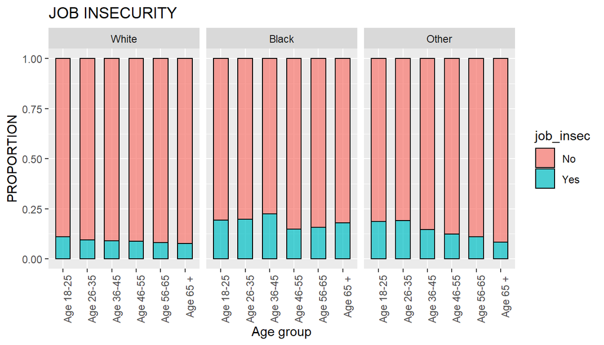

The side-by-side stacked bar plot shows the distribution of Job insecurity across the various age groups & race.

From the plot it appears that:

1. The proportion of White Americans who feel insecure in their jobs decreases with increase in age.
2. The proportion of Black Americans who feel insecure in their jobs initially increases with increase in age and is maximum for the age group “Age 36-45” then dips to its minimum for the age group “Age 46-55”. Post this it steadily rises again.
3. The percentage of White Americans who feel insecure about their job are lesser than the percentage of Black Americans across each age group. Though the difference is observed in the graph, it is difficult to conclude if this difference is **statistically significant** or not.

## Part 4.2: Inference

We set the hypothesis test, at 5 % significance level as:

$H_0$ (Nothing going on): Race & the feeling of insecurity in a job are independent.

$H_A$ (Something going on): Race & the feeling of insecurity in a job are dependent.

The contingency table for the two variables of interest looks like:

| CONTINGENCY TABLE 2: FEELING INSECURE FOR JOB | CONTINGENCY TABLE 2: FEELING INSECURE FOR JOB Age 18-25 | CONTINGENCY TABLE 2: FEELING INSECURE FOR JOB Age 26-35 | CONTINGENCY TABLE 2: FEELING INSECURE FOR JOB Age 36-45 | CONTINGENCY TABLE 2: FEELING INSECURE FOR JOB Age 46-55 | CONTINGENCY TABLE 2: FEELING INSECURE FOR JOB Age 56-65 | CONTINGENCY TABLE 2: FEELING INSECURE FOR JOB Age 65+ | CONTINGENCY TABLE 2: FEELING INSECURE FOR JOB Total |
| --- | --- | --- | --- | --- | --- | --- | --- |
| White | 216 | 384 | 355 | 269 | 139 | 39 | 1402 |
| Black | 59 | 149 | 142 | 69 | 36 | 9 | 464 |
| Total | 275 | 533 | 497 | 338 | 175 | 48 | 1866 |

**Checking for Conditions:**

**1. Independence: Sampled observations must be independent**

Since the individuals were randomly sampled without replacement, each individual contributes to only one cell in the table & since sample population < 10% of the US population, this condition is met.

**2. Sample size:Each particular scenario must have at least 5 expected cases**

Referring to the table, we see that all the values > 5 & hence conclude that this condition is met as well.

**Since the conditions are met, we can now proceed with the Chi-square test of independence.**

```
##
##  Pearson's Chi-squared test
##
## data:  df2.3$race and df2.3$age_grp
## X-squared = 14.362, df = 5, p-value = 0.01347
```

**Conclusion:**

Since the p_value < 0.05 for the set significance level, we reject the null hypothesis in favor of the alternative.

## Part 2.3: Research question 3:

“The increase in household size is significant because it could have implications for national economic growth” says Richard Fry, Senior Researcher [PEW Research Centre, Fact-Tank](https://www.pewresearch.org/fact-tank/2019/10/01/the-number-of-people-in-the-average-u-s-household-is-going-up-for-the-first-time-in-over-160-years/)

**Has the average family size in US changed over the decades?**

In general one can anticipate that the number of households are increasing as can be seen from the rise in population. However, what remains to be determined is if the number of members per household have increased over the past multiple decades?

A significant rise in number of people per household could result in a rise in the poverty line. This could impact the nation’s economic growth and necessitate the development of new policies.

## Part 3.3: Exploratory data analysis

**DIRECT VARIABLES FROM GSS SURVEY DATABASE**

1. `age:` indicates the age of a respondent in years
2. `year:` indicates the year of the survey
3. `childs:` indicates the # of children in the family, an indicator of family size

We start by picking up the variables of interest for the data set.

**One important thing to note is that we would be considering individual over the age of 35 years for this analysis, since this is the age around which the family size usually gets defined.**

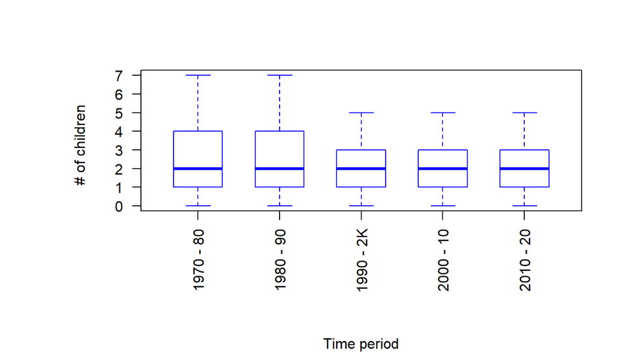

The side-by-side box-plot highlights the following:

1. Since the distribution of # of children in a household cannot be less than 0, it has a natural boundary of 0 at the bottom. The data is expected to have some right-skewness which is evident from the plots.
2. The right-skewness seems to be evident in the earlier decades until the 90’s post which data seems to be nearly normal.
3. The family sizes were larger until the 90’s post which they seem to have remained fairly constant. Also the data until 90’s shows more variability compared to the later decades.

## Part 4.3: Inference

Since we are dealing with one numerical & one categorical variable with more than 2 levels, we shall use **ANOVA** to compare the means across several groups.

**Has the average family size in US changed over the decades?**

We set the hypothesis test, at 5 % significance level as:

$H_0$ (Nothing going on): Average family size has remained constant over the decades.

$H_A$ (Something going on): Average family size between atleast one pair of time periods has changed.

```
## # A tibble: 5 x 4
##   yr_grp        n  Mean Std_dev
## * <chr>     <int> <dbl>   <dbl>
## 1 1970 - 80  7668  2.72    2.00
## 2 1980 - 90  9027  2.56    1.92
## 3 1990 - 2K 10084  2.24    1.72
## 4 2000 - 10 10134  2.22    1.70
## 5 2010 - 20  1433  2.23    1.68
```

**Checking for Conditions:**

**1. Independence:Sampled observations must be independent of each other**

**a. Within groups:** Since the individuals were randomly sampled without replacement & since for each time period, the total # of individuals < 10% of the US population, this condition is met.

**b. Between groups:** Since only one person from each household was interviewed, the two groups are independent of each other.

**2. Approximate normality: Distributions should be nearly normal within each group**

**3. Equal variance: Groups should have roughly equal variability**

Looking at the side-by-side box-plots & values of the standard deviation in the summary table, we can conclude that the variability between the groups are roughly equal.

**Since the conditions are met, we can now proceed with the ANOVA test.**

```
##                 Df Sum Sq Mean Sq F value Pr(>F)
## df3.1$yr_grp     4   1601   400.4   120.8 <2e-16 ***
## Residuals    38341 127105     3.3
## ---
## Signif. codes:  0 '***' 0.001 '**' 0.01 '*' 0.05 '.' 0.1 ' ' 1
```

**Conclusion:**

Since the p_value < 0.05 for the set significance level, we reject the null hypothesis in favor of the alternative.

Thus we conclude that for atleast one of the pairs of time period, the average family size has changed.

We would also want to know for which pairs of time period the average family size has changed.  
**Applying Bonferroni correction:**

The **Bonferroni correction** suggests that a more stringent significance level ($\alpha^*$) is appropriate for testing many pairs of groups:  
$\alpha^*$ = $\alpha$ / K, where $\alpha$ = significance level set for ANOVA & K: # of paired t-tests required  
$K = k(k-1)/2,$ where k: # of levels of the categorical variable  
$K = 5 X 4 / 2 = 10$  
$\alpha^* = 0.05/10 = 0.005$… the new significance level  
Conducting the Pairwise t.test for the data we get:

```
##
##  Pairwise comparisons using t tests with pooled SD
##
## data:  df3.1$childs and df3.1$yr_grp
##
##           1970 - 80 1980 - 90 1990 - 2K 2000 - 10
## 1980 - 90 3.1e-07   -         -         -
## 1990 - 2K < 2e-16   < 2e-16   -         -
## 2000 - 10 < 2e-16   < 2e-16   1         -
## 2010 - 20 < 2e-16   2.7e-09   1         1
##
## P value adjustment method: bonferroni
```

**Conclusion:**

1. The summary table gives the p_value for all the 10 pair combinations.
2. We can see that the p_value for all the pairs with **Period 1970 - 80** & **Period 1980 - 90** are less than the set significance level of 0.005. Thus, the average size of the families for these periods are different from each other as well as the rest of the periods.
3. We can see that the $p_{value}$ for all remaining pairs with **Period 1990 - 2K, Period 2000 - 10 & Period 2010-20** are greater than the set significance level of 0.005. Thus, the average size of the families for these periods seem to be the same.